# SA1 DSC1107

Lindsay Faith Bazar

March 19, 2025

```r
suppressPackageStartupMessages(suppressWarnings({
library(tidyverse)
library(caret)
library(glmnet)
library(ggplot2)
}))
```

## Unit 1: R for Data Mining

#### 1. Intro to Modern Data Mining

```r
data <- read.csv("customer_churn.csv")

sum(is.na(data))
```

```
## [1] 0
```

```r
dim(data)
```

```
## [1] 10000    12
```

```r
str(data)
```

```
## 'data.frame':    10000 obs. of  12 variables:
##  $ CustomerID     : chr  "CUST00001" "CUST00002" "CUST00003" "CUST00004" ...
##  $ Gender         : chr  "Male" "Male" "Male" "Female" ...
##  $ SeniorCitizen  : int  0 0 0 0 0 0 0 0 0 0 ...
##  $ Partner        : chr  "No" "No" "Yes" "Yes" ...
##  $ Dependents     : chr  "No" "No" "No" "Yes" ...
##  $ Tenure         : int  65 26 54 70 53 45 35 20 48 33 ...
##  $ PhoneService   : chr  "Yes" "Yes" "Yes" "Yes" ...
##  $ InternetService: chr  "Fiber optic" "Fiber optic" "Fiber optic" "DSL" ...
##  $ Contract       : chr  "Month-to-month" "Month-to-month" "Month-to-month" "One year" ...
##  $ MonthlyCharges : num  20 65.1 49.4 31.2 103.9 ...
##  $ TotalCharges   : num  1303 1694 2667 2183 5505 ...
##  $ Churn          : chr  "No" "No" "No" "No" ...
```

```r
summary(data)
```

```
##   CustomerID           Gender          SeniorCitizen      Partner
##  Length:10000       Length:10000       Min.   :0.0000   Length:10000
##  Class :character   Class :character   1st Qu.:0.0000   Class :character
##  Mode  :character   Mode  :character   Median :0.0000   Mode  :character
##                                        Mean   :0.1502
##                                        3rd Qu.:0.0000
##                                        Max.   :1.0000
##   Dependents            Tenure      PhoneService       InternetService
##  Length:10000       Min.   : 0.00   Length:10000       Length:10000
##  Class :character   1st Qu.:17.00   Class :character   Class :character
##  Mode  :character   Median :35.00   Mode  :character   Mode  :character
##                     Mean   :35.22
##                     3rd Qu.:53.00
##                     Max.   :71.00
##    Contract         MonthlyCharges    TotalCharges       Churn
##  Length:10000       Min.   : 20.02   Min.   :   0.0   Length:10000
##  Class :character   1st Qu.: 44.88   1st Qu.: 961.2   Class :character
##  Mode  :character   Median : 70.56   Median :2025.6   Mode  :character
##                     Mean   : 70.18   Mean   :2455.8
##                     3rd Qu.: 95.77   3rd Qu.:3611.0
##                     Max.   :119.99   Max.   :8425.6
```

```r
head(data)
```

```
##   CustomerID Gender SeniorCitizen Partner Dependents Tenure PhoneService
## 1  CUST00001   Male             0      No         No     65          Yes
## 2  CUST00002   Male             0      No         No     26          Yes
## 3  CUST00003   Male             0     Yes         No     54          Yes
## 4  CUST00004 Female             0     Yes        Yes     70          Yes
## 5  CUST00005   Male             0      No         No     53          Yes
## 6  CUST00006 Female             0      No        Yes     45          Yes
##   InternetService       Contract MonthlyCharges TotalCharges Churn
## 1     Fiber optic Month-to-month          20.04      1302.60    No
## 2     Fiber optic Month-to-month          65.14      1693.64    No
## 3     Fiber optic Month-to-month          49.38      2666.52    No
## 4             DSL       One year          31.19      2183.30    No
## 5             DSL Month-to-month         103.86      5504.58   Yes
## 6     Fiber optic Month-to-month          87.34      3930.30   Yes
```

The dataset contains 10,000 rows and 12 columns with no missing values. It includes customer information such as gender, senior citizen status, partner, dependents, tenure, phone and internet services, contract type, monthly and total charges, and churn status.

Why data mining is important for this dataset?

Data mining helps discover reasons why customers stop using the service by analyzing factors like tenure, monthly charges, and internet service. It also helps predict which customers are likely to leave so the company can take action to keep them. In short, Data mining helps the company understand and prevent customer churn, improving overall business performance.

#### 2. Data Visualization

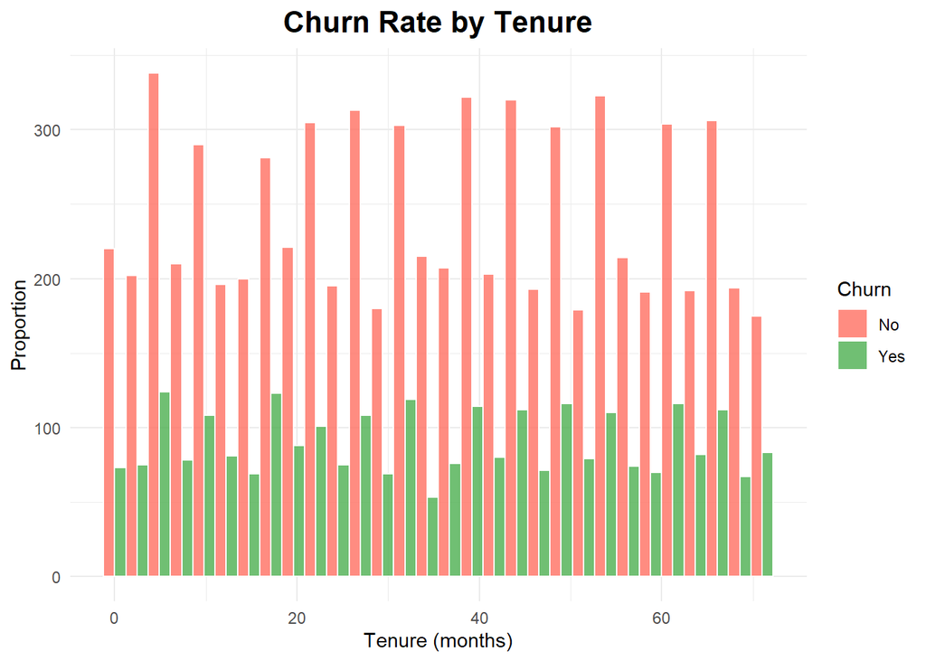

```r
ggplot(data, aes(x = Tenure, fill = Churn)) +
  geom_histogram(bins = 30, color = "white", alpha = 0.8, position = "dodge") +
  scale_fill_manual(values = c("#FF6F61", "#4CAF50")) +
  theme_minimal() +
  labs(title = "Churn Rate by Tenure", x = "Tenure (months)", y = "Proportion") +
  theme(plot.title = element_text(hjust = 0.5, face = "bold", size = 16))
```

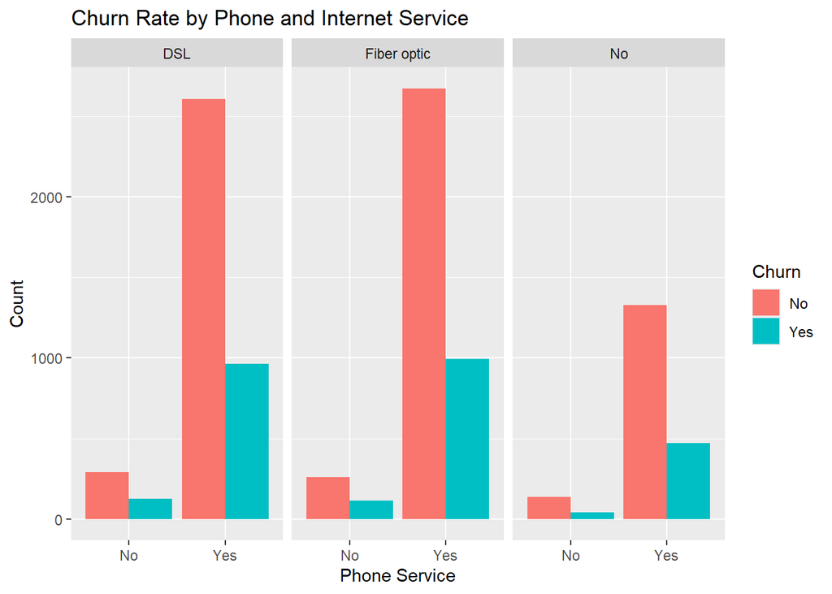

```r
ggplot(data, aes(x = PhoneService, fill = Churn)) +
  geom_bar(position = "dodge") +
  facet_wrap(~InternetService) +
  labs(title = "Churn Rate by Phone and Internet Service", x = "Phone Service", y = "Count")
```

DSL and Fiber Optic Users:

- More customers did not churn (No) than those who churned (Yes).
- Fiber optic users have a slightly higher number of churns compared to DSL users.

Overall, Fiber optic users have the highest churn count, suggesting they may be more likely to leave compared to DSL or those without internet.

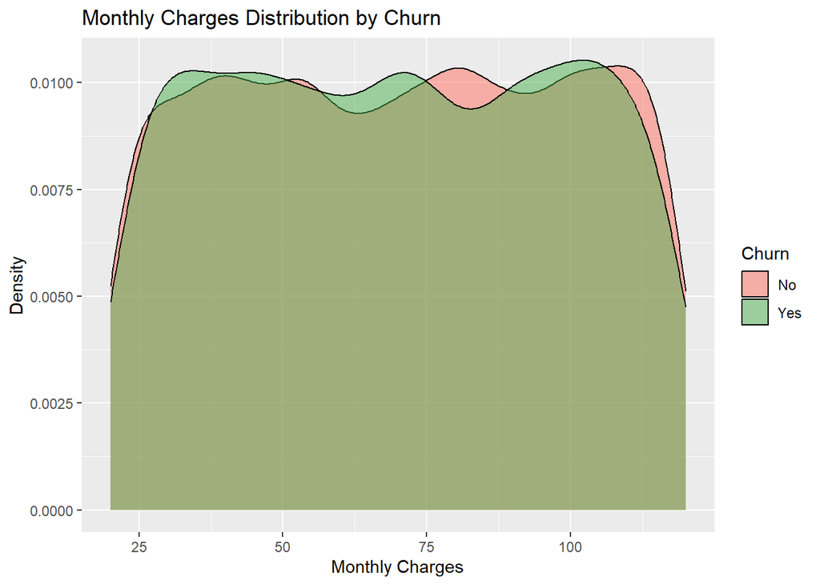

```r
ggplot(data, aes(x = MonthlyCharges, fill = Churn)) +
  geom_density(alpha = 0.5) +
  scale_fill_manual(values = c("No" = "#FF6F61", "Yes" = "#4CAF50")) +
  labs(title = "Monthly Charges Distribution by Churn", x = "Monthly Charges", y = "Density")
```

The density plot shows the distribution of Monthly Charges for customers who churned (Yes) and those who did not churn (No).

Both groups have a similar distribution across Monthly Charges. There is no strong difference between the churn and non-churn groups for most charge ranges. Some slight variations exist where churn rates are slightly higher or lower at specific points, but overall, the densities overlap a lot.

#### 3. Data Transformation

I noticed that the Senior Citizen values are either 0 or 1 earlier, which we will switch to Yes and No for consistency.

```r
data$SeniorCitizen <- ifelse(data$SeniorCitizen == 1, "Yes", "No")
head(data$SeniorCitizen)
```

```
## [1] "No" "No" "No" "No" "No" "No"
```

Handle missing values appropriately.

```r
sum(is.na(data))
```

```
## [1] 0
```

There are no missing values so we will proceed.

Convert categorical variables into factor variables.

```r
data$Churn <- as.factor(data$Churn)
data$PhoneService <- as.factor(data$PhoneService)
data$InternetService <- as.factor(data$InternetService)
data$Gender <- as.factor(data$Gender)
data$Partner <- as.factor(data$Partner)
data$Dependents <- as.factor(data$Dependents)
data$Contract <- as.factor(data$Contract)
```

Normalize or standardize numerical features where necessary.

```r
data$MonthlyCharges <- scale(data$MonthlyCharges)
data$TotalCharges<- scale(data$TotalCharges)
data$Tenure <- scale(data$Tenure)
```

#### 4. Data Wrangling

```r
data <- data %>% filter(MonthlyCharges < quantile(MonthlyCharges, 0.99))


data <- data %>%
  mutate(TenureGroup = cut(Tenure,
    breaks = quantile(Tenure, probs = c(0, 0.25, 0.5, 0.75, 1)),
    labels = c("Low Tenure", "Medium Tenure", "High Tenure", "Loyal Customers"),
    include.lowest = TRUE
  ))

table(data$TenureGroup)
```

```
##
##      Low Tenure   Medium Tenure     High Tenure Loyal Customers
##            2485            2487            2482            2446
```

## 2. Unit 2: Tuning Predictive Models

#### 6. Model Complexity

```r
library(rpart)

set.seed(123)
trainIndex <- createDataPartition(data$Churn, p = 0.8, list = FALSE)
trainData <- data[trainIndex, ]
testData <- data[-trainIndex, ]

logit_model <- glm(Churn ~ Tenure + MonthlyCharges + TotalCharges, data = trainData, family = "binomial")
summary(logit_model)
```

```
##
## Call:
## glm(formula = Churn ~ Tenure + MonthlyCharges + TotalCharges,
##     family = "binomial", data = trainData)
##
## Coefficients:
##                 Estimate Std. Error z value Pr(>|z|)
## (Intercept)    -0.992841   0.025311 -39.226   <2e-16 ***
## Tenure          0.077910   0.065681   1.186    0.236
## MonthlyCharges  0.005202   0.050809   0.102    0.918
## TotalCharges   -0.070570   0.078602  -0.898    0.369
## ---
## Signif. codes:  0 '***' 0.001 '**' 0.01 '*' 0.05 '.' 0.1 ' ' 1
##
## (Dispersion parameter for binomial family taken to be 1)
##
##     Null deviance: 9248.6  on 7920  degrees of freedom
## Residual deviance: 9245.0  on 7917  degrees of freedom
## AIC: 9253
##
## Number of Fisher Scoring iterations: 4
```

```r
testData$TotalCharges[is.na(testData$TotalCharges)] <- median(testData$TotalCharges, na.rm=TRUE)

tree_model <- rpart(Churn ~ Tenure + MonthlyCharges + TotalCharges + Gender + Partner + Dependents + PhoneService + InternetService + Contract,
                             data = testData,
                             method = "class",
                             control = rpart.control(cp = 0, maxdepth = 5))

summary(tree_model)
```

```
## Call:
## rpart(formula = Churn ~ Tenure + MonthlyCharges + TotalCharges +
##     Gender + Partner + Dependents + PhoneService + InternetService +
##     Contract, data = testData, method = "class", control = rpart.control(cp = 0,
##     maxdepth = 5))
##   n= 1979
##
##            CP nsplit rel error   xerror       xstd
## 1 0.001869159      0 1.0000000 1.000000 0.03693038
## 2 0.001401869      7 0.9869159 1.014953 0.03710227
## 3 0.000000000     11 0.9813084 1.028037 0.03724953
##
## Variable importance
##   TotalCharges         Tenure MonthlyCharges     Dependents
##             53             26             18              4
##
## Node number 1: 1979 observations,    complexity param=0.001869159
##   predicted class=No   expected loss=0.2703386  P(node) =1
##     class counts:  1444   535
##    probabilities: 0.730 0.270
##   left son=2 (1434 obs) right son=3 (545 obs)
##   Primary splits:
##       MonthlyCharges < 0.716577   to the left,  improve=4.1614900, (0 missing)
##       TotalCharges   < 2.672056   to the right, improve=2.5063500, (0 missing)
##       Tenure         < -1.62218   to the right, improve=1.0708980, (0 missing)
##       Gender         splits as  RL, improve=0.5834055, (0 missing)
##       Contract       splits as  LLR, improve=0.5694351, (0 missing)
##   Surrogate splits:
##       TotalCharges < 1.327113   to the left,  agree=0.796, adj=0.259, (0 split)
##
## Node number 2: 1434 observations,    complexity param=0.001869159
##   predicted class=No   expected loss=0.2503487  P(node) =0.7246084
##     class counts:  1075   359
##    probabilities: 0.750 0.250
##   left son=4 (41 obs) right son=5 (1393 obs)
##   Primary splits:
##       TotalCharges    < 1.366461   to the right, improve=3.4296980, (0 missing)
##       Tenure          < -1.62218   to the right, improve=2.1022850, (0 missing)
##       MonthlyCharges  < 0.02275565 to the right, improve=1.8825060, (0 missing)
##       Dependents      splits as  RL, improve=1.0985420, (0 missing)
```

[output cut: 174 more lines]

```
##
## Node number 45: 7 observations
##   predicted class=Yes  expected loss=0.2857143  P(node) =0.00353714
##     class counts:     2     5
##    probabilities: 0.286 0.714
##
## Node number 62: 336 observations
##   predicted class=No   expected loss=0.3482143  P(node) =0.1697827
##     class counts:   219   117
##    probabilities: 0.652 0.348
##
## Node number 63: 57 observations
##   predicted class=Yes  expected loss=0.4736842  P(node) =0.02880243
##     class counts:    27    30
##    probabilities: 0.474 0.526
```

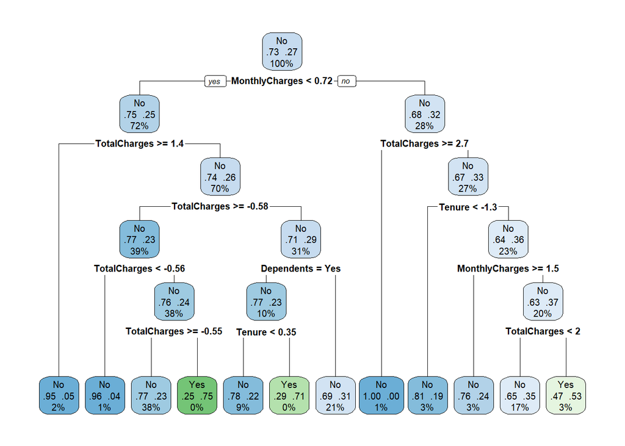

```r
library(rpart.plot)

rpart.plot(tree_model, type = 2, extra = 104, fallen.leaves = TRUE)
```

#### 7. Bias-Variance Trade-Off

- Tradeoff

Bias: Model is too simple, and misses patterns (underfitting). Just like the Logistic Regression that is lower variance but with higher bias.

Variance: Model is too complex and captures noise (overfitting). Just like the Decision Tree, lower bias but higher variance.

- Effect of Complexity:

Low Complexity: Misses patterns → perform poorly.

High Complexity: Too detailed → loses generalization.

#### 8. Cross Validation

```r
ctrl <- trainControl(method = "cv", number = 10)


set.seed(123)
logit_model_cv <- train(Churn ~ Tenure + MonthlyCharges + TotalCharges,
                        data = trainData,
                        method = "glm",
                        family = "binomial",
                        trControl = ctrl)

pred_logit <- predict(logit_model_cv, testData)

conf_matrix_logit <- confusionMatrix(pred_logit, testData$Churn)
conf_matrix_logit
```

```
## Confusion Matrix and Statistics
##
##           Reference
## Prediction   No  Yes
##        No  1444  535
##        Yes    0    0
##
##                Accuracy : 0.7297
##                  95% CI : (0.7095, 0.7491)
##     No Information Rate : 0.7297
##     P-Value [Acc > NIR] : 0.5116
##
##                   Kappa : 0
##
##  Mcnemar's Test P-Value : <2e-16
##
##             Sensitivity : 1.0000
##             Specificity : 0.0000
##          Pos Pred Value : 0.7297
##          Neg Pred Value :    NaN
##              Prevalence : 0.7297
##          Detection Rate : 0.7297
##    Detection Prevalence : 1.0000
##       Balanced Accuracy : 0.5000
##
##        'Positive' Class : No
##
```

```r
logit_metrics <- data.frame(
  Accuracy = conf_matrix_logit$overall["Accuracy"],
  Precision = conf_matrix_logit$byClass["Pos Pred Value"],
  Recall = conf_matrix_logit$byClass["Sensitivity"],
  F1_Score = 2 * ((conf_matrix_logit$byClass["Pos Pred Value"] * conf_matrix_logit$byClass["Sensitivity"]) /
                   (conf_matrix_logit$byClass["Pos Pred Value"] + conf_matrix_logit$byClass["Sensitivity"]))
)
logit_metrics
```

```
##           Accuracy Precision Recall  F1_Score
## Accuracy 0.7296614 0.7296614      1 0.8437044
```

#### 9. Classification

```r
library(randomForest)

set.seed(42)
rf_model <- randomForest(Churn ~ ., data = trainData, ntree = 100, mtry = 3, importance = TRUE)

print(rf_model)
```

```
##
## Call:
##  randomForest(formula = Churn ~ ., data = trainData, ntree = 100,      mtry = 3, importance = TRUE)
##                Type of random forest: classification
##                      Number of trees: 100
## No. of variables tried at each split: 3
##
##         OOB estimate of  error rate: 28.51%
## Confusion matrix:
##       No Yes class.error
## No  5607 171  0.02959502
## Yes 2087  56  0.97386841
```

```r
rf_pred <- predict(rf_model, testData)

rf_cm <- confusionMatrix(rf_pred, testData$Churn, positive = "Yes")
print(rf_cm)
```

```
## Confusion Matrix and Statistics
##
##           Reference
## Prediction   No  Yes
##        No  1420  530
##        Yes   24    5
##
##                Accuracy : 0.7201
##                  95% CI : (0.6997, 0.7398)
##     No Information Rate : 0.7297
##     P-Value [Acc > NIR] : 0.8382
##
##                   Kappa : -0.0104
##
##  Mcnemar's Test P-Value : <2e-16
##
##             Sensitivity : 0.009346
##             Specificity : 0.983380
##          Pos Pred Value : 0.172414
##          Neg Pred Value : 0.728205
##              Prevalence : 0.270339
##          Detection Rate : 0.002527
##    Detection Prevalence : 0.014654
##       Balanced Accuracy : 0.496363
##
##        'Positive' Class : Yes
##
```

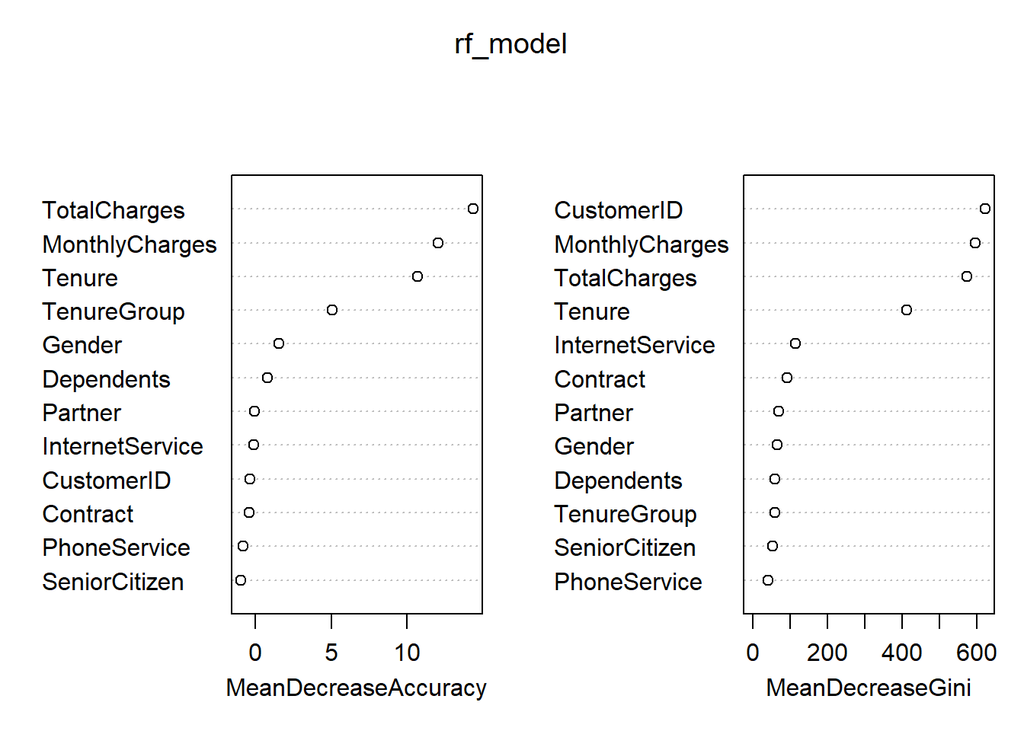

```r
varImpPlot(rf_model)
```

## 3. Unit 3: Regression-Based Methods

#### 10. Logistic Regression

```r
logit_model <- glm(Churn ~ Tenure + MonthlyCharges + TotalCharges,
                   data = trainData,
                   family = binomial)

summary(logit_model)
```

```
##
## Call:
## glm(formula = Churn ~ Tenure + MonthlyCharges + TotalCharges,
##     family = binomial, data = trainData)
##
## Coefficients:
##                 Estimate Std. Error z value Pr(>|z|)
## (Intercept)    -0.992841   0.025311 -39.226   <2e-16 ***
## Tenure          0.077910   0.065681   1.186    0.236
## MonthlyCharges  0.005202   0.050809   0.102    0.918
## TotalCharges   -0.070570   0.078602  -0.898    0.369
## ---
## Signif. codes:  0 '***' 0.001 '**' 0.01 '*' 0.05 '.' 0.1 ' ' 1
##
## (Dispersion parameter for binomial family taken to be 1)
##
##     Null deviance: 9248.6  on 7920  degrees of freedom
## Residual deviance: 9245.0  on 7917  degrees of freedom
## AIC: 9253
##
## Number of Fisher Scoring iterations: 4
```

```r
pred_logit_prob <- predict(logit_model, testData, type = "response")

pred_logit <- ifelse(pred_logit_prob > 0.5, "Yes", "No")

conf_matrix_logit <- confusionMatrix(as.factor(pred_logit), testData$Churn)
conf_matrix_logit
```

```
## Confusion Matrix and Statistics
##
##           Reference
## Prediction   No  Yes
##        No  1444  535
##        Yes    0    0
##
##                Accuracy : 0.7297
##                  95% CI : (0.7095, 0.7491)
##     No Information Rate : 0.7297
##     P-Value [Acc > NIR] : 0.5116
##
##                   Kappa : 0
##
##  Mcnemar's Test P-Value : <2e-16
##
##             Sensitivity : 1.0000
##             Specificity : 0.0000
##          Pos Pred Value : 0.7297
##          Neg Pred Value :    NaN
##              Prevalence : 0.7297
##          Detection Rate : 0.7297
##    Detection Prevalence : 1.0000
##       Balanced Accuracy : 0.5000
##
##        'Positive' Class : No
##
```

The logistic regression model shows that none of the predictors (Tenure, MonthlyCharges, and TotalCharges) significantly affect churn, as all p-values are greater than 0.05. The intercept suggests a higher likelihood of no churn when all predictors are zero. The small difference between null and residual deviance indicates that the model explains very little variation in the data, and the AIC value of 9253 suggests a weak model. Overall, the model is not statistically significant, and further improvements or additional variables may be needed for better prediction.

#### 11. Regression in High Dimensions

```r
library(factoextra)

num_features <- trainData %>%
  select(Tenure, MonthlyCharges, TotalCharges)

pca_model <- prcomp(num_features, center = TRUE, scale. = TRUE)

summary(pca_model)
```

```
## Importance of components:
##                           PC1    PC2     PC3
## Standard deviation     1.3839 1.0154 0.23151
## Proportion of Variance 0.6384 0.3437 0.01787
## Cumulative Proportion  0.6384 0.9821 1.00000
```

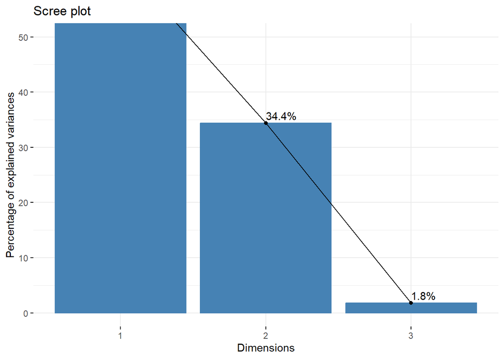

```r
fviz_eig(pca_model, addlabels = TRUE, ylim = c(0, 50))
```

```r
trainData_pca <- cbind(trainData, pca_model$x[, 1:2])
testData_pca <- predict(pca_model, newdata = testData)
```

#### 12. Ridge Regression

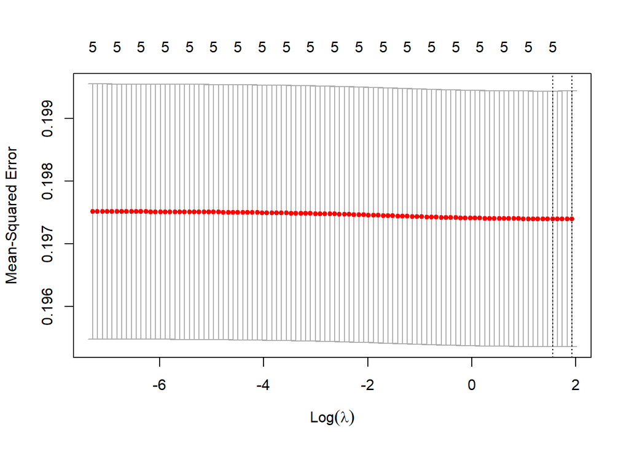

```r
library(glmnet)

x_train <- model.matrix(Churn ~ Tenure + MonthlyCharges + TotalCharges + Gender + SeniorCitizen, data = trainData)[, -1]
y_train <- ifelse(trainData$Churn == "Yes", 1, 0)

set.seed(123)
ridge_model <- cv.glmnet(x_train, y_train, alpha = 0)

plot(ridge_model)
```

Optimal lambda:

```r
optimal_lambda_ridge <- ridge_model$lambda.min
optimal_lambda_ridge
```

```
## [1] 4.721362
```

```r
ridge_final <- glmnet(x_train, y_train, alpha = 0, lambda = optimal_lambda_ridge)
ridge_final
```

```
##
## Call:  glmnet(x = x_train, y = y_train, alpha = 0, lambda = optimal_lambda_ridge)
##
##   Df %Dev Lambda
## 1  5 0.01  4.721
```

#### 13. Lasso Regression

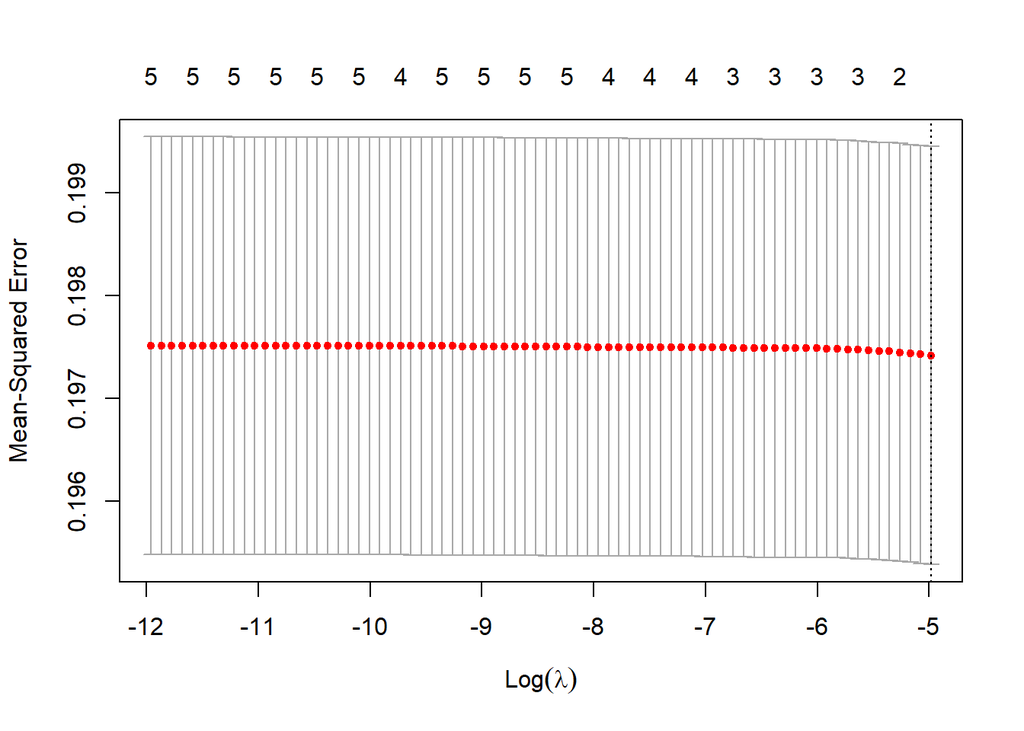

```r
set.seed(123)
lasso_model <- cv.glmnet(x_train, y_train, alpha = 1)

plot(lasso_model)
```

```r
best_lambda_lasso <- lasso_model$lambda.min
best_lambda_lasso
```

```
## [1] 0.006849888
```

```r
lasso_final <- glmnet(x_train, y_train, alpha = 1, lambda = best_lambda_lasso)
lasso_final
```

```
##
## Call:  glmnet(x = x_train, y = y_train, alpha = 1, lambda = best_lambda_lasso)
##
##   Df %Dev  Lambda
## 1  1    0 0.00685
```

```r
lasso_coefs <- predict(lasso_final, type = "coefficients", s = best_lambda_lasso)
lasso_coefs
```

```
## 6 x 1 sparse Matrix of class "dgCMatrix"
##                             s1
## (Intercept)       2.705466e-01
## Tenure            .
## MonthlyCharges   -3.110399e-18
## TotalCharges      .
## GenderMale        .
## SeniorCitizenYes  .
```

Generally, the LASSO regression results show that most of the features were not important for predicting the outcome, as their coefficients were reduced to zero. This means that Tenure, TotalCharges, GenderMale, and SeniorCitizenYes did not contribute much to the model’s predictions. The only feature with a small effect was MonthlyCharges, but even that was close to zero.